# Problem statement :-

## Text preprocessing 🛞

```python
stop_words = set(stopwords.words('english'))
```

```python
## applying the stemming and wordtokenizer for the review column
def preprocess_text(text):
    wordz=nltk.word_tokenize(text) #tokenizing
    wordz=[content for content in wordz if content not in stop_words]
    return ' '.join(wordz)
```

df_movie['review'].apply(preprocess_text)

```python
df_movie['review']=df_movie['review'].apply(preprocess_text)
```

```python
#transformed Data  & copy of main dataset
print(f' Before changes:-\n',df_main['review'][2])
print('***********************************************')
print(f' After changes :-\n',df_movie['review'][2])
```

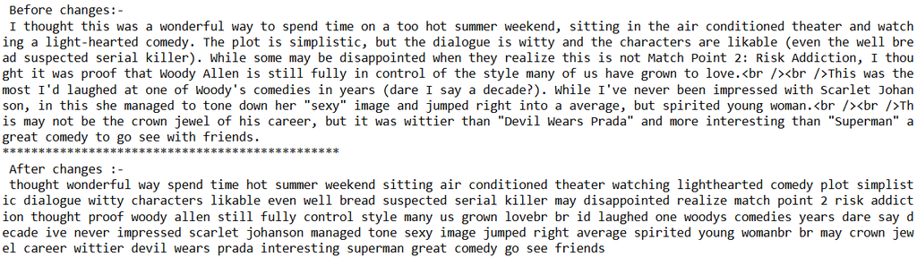

```python
wx=WordCloud(width=499,height=499,min_font_size=10.5,background_color='white')
```

```python
positive_wc=wx.generate(df_movie[df_movie['sentiment']=='positive']['review'].str.cat(sep=" "))
```

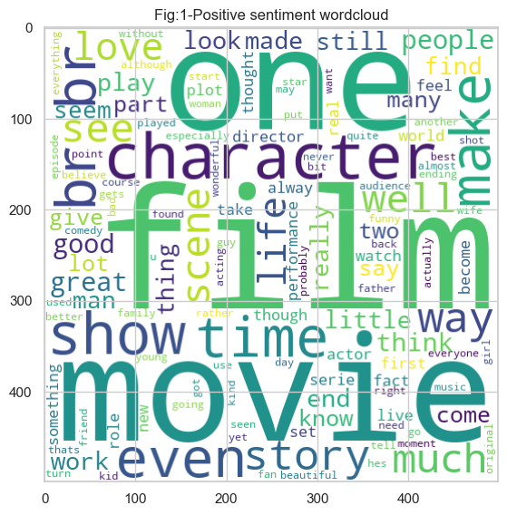

```python
px.figure(figsize=(14,6.5))
px.title('Fig:1-Positive sentiment wordcloud');
px.imshow(positive_wc);
```

```python
negative_wc=wx.generate(df_movie[df_movie['sentiment']=='negative']['review'].str.cat(sep=" "))
```

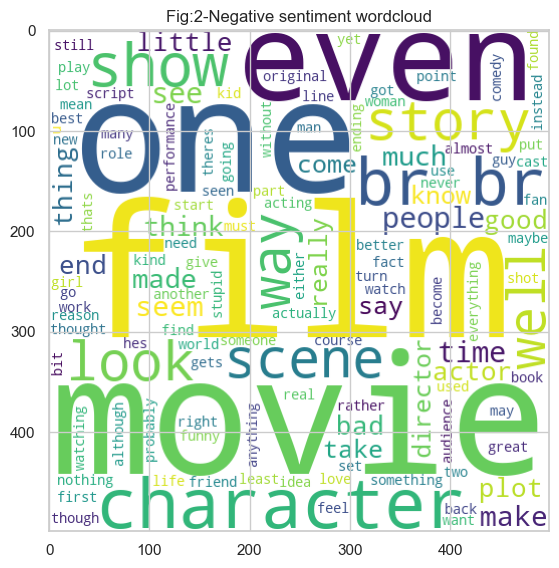

```python
px.figure(figsize=(14,6.5))
px.title('Fig:2-Negative sentiment wordcloud');
px.imshow(negative_wc);
```

#### comments🕵️♀

🚩 The above wordcloud represents the most frequent words in positive and in negative reviews in our Dataset 🎞️

🚩 a)Fig-1 represents the positive reviews the common words used here are [film,movie,character,one,look,people etc.,]🎬 and

🚩 b)Fig-2 represents the negative reviews common words used here are [film,story,well,br,think,story,scene,show etc.,] 📽️

## Feature Engineering 🪛

```python
X =df_movie.iloc[:,0:1]
y=df_movie['sentiment']
```

```python
##Converting the target column to Binary array
encode = LabelEncoder()
y= encode.fit_transform(y)
```

#### endoded target column

```python
print(y)
```

```
[1 1 1 ... 0 0 0]
```

#### splittingup the data into test-data and training data

```python
X_training,X_testing,y_training,y_testing = train_test_split(X,y,test_size=0.22,random_state=1)
```

```python
X_training.shape
```

```
(38673, 1)
```

#### Applying the Bag of Words 🔠

#### using top 10000 most frequent words in the vocabulary for Dimenstionality reduction,improve performance & noise reduction.

```python
CountVect= CountVectorizer(max_features=10000)
```

```python
X_training_bow= CountVect.fit_transform(X_training['review']).toarray()
X_testing_bow= CountVect.transform(X_testing['review']).toarray()
```

```python
X_training_bow.shape
```

```
(38673, 10000)
```

## Model Training 🤖

### Using GaussianNB and bagofwords

```python
## training the model
gnb = GaussianNB()
```

```python
gnb.fit(X_training_bow,y_training)
```

```
GaussianNB()
```

```python
y_prediction = gnb.predict(X_testing_bow)
accuracy_scoring_bow=accuracy_score(y_testing,y_prediction)
accuracy_scoring_bow
```

```
0.7411311760931341
```

```python
confusion_matrix(y_testing,y_prediction)
```

```
array([[4767,  764],
       [2060, 3318]], dtype=int64)
```

### Using Randomforest and bagofwords

```python
rfc= RandomForestClassifier()
```

```python
rfc.fit(X_training_bow,y_training)
```

```
RandomForestClassifier()
```

```python
yrf_prediction = rfc.predict(X_testing_bow)
accuracy_scoring_rfbow=accuracy_score(y_testing,yrf_prediction )
accuracy_scoring_rfbow
```

```
0.8532404436703639
```

```python
confusion_matrix(y_testing,yrf_prediction)
```

```
array([[4725,  806],
       [ 795, 4583]], dtype=int64)
```

### summary model training

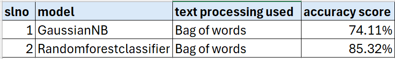

## Improvements 🧬

#### Applying the TFIDF ☑️

```python
## Using the TFIDF
tfidf = TfidfVectorizer(max_features=10000)
```

```python
X_training_tfidf= tfidf.fit_transform(X_training['review']).toarray()
X_testing_tfidf= tfidf.transform(X_testing['review']).toarray()
```

```python
rftfidf= RandomForestClassifier(random_state=42)
rftfidf.fit(X_training_tfidf,y_training)
```

```
RandomForestClassifier(random_state=42)
```

```python
yrf_predect_improv = rftfidf.predict(X_testing_tfidf)
```

```python
accurac_score_tfidf=accuracy_score(y_testing,yrf_predect_improv )
accurac_score_tfidf
```

```
0.852048767073059
```

```python
confusion_matrix(y_testing,yrf_predect_improv)
```

```
array([[4752,  779],
       [ 835, 4543]], dtype=int64)
```

#### Applying the N-gram ☑️

```python
## Using the bigram
cv_grams= CountVectorizer(max_features=10000,ngram_range=(1,2))
```

```python
X_training_ngrams= cv_grams.fit_transform(X_training['review']).toarray()
X_testing_ngrams= cv_grams.transform(X_testing['review']).toarray()
```

```python
## Hyperparametertuning of the RandomForestmodel:-
parameters_rfn = {
    'n_estimators': [10, 50],
    'max_features': ['sqrt', 'log2'],
    'max_depth': [10, 20],
    'min_samples_split': [2, 3,]
}
```

```python
rfn= RandomForestClassifier(random_state=42)
```

```python
grid_cvn=GridSearchCV(param_grid=parameters_rfn,estimator=rfn,scoring='accuracy',cv=3,n_jobs=1)
```

```python
 grid_cvn.fit(X_training_ngrams,y_training)
```

```
GridSearchCV(cv=3, estimator=RandomForestClassifier(random_state=42), n_jobs=1,
             param_grid={'max_depth': [10, 20],
                         'max_features': ['sqrt', 'log2'],
                         'min_samples_split': [2, 3],
                         'n_estimators': [10, 50]},
             scoring='accuracy')
```

```python
# The best parameters identified by our hyperparametertuning are :-
print(f'Best Parameters are: {grid_cvn.best_params_}')
```

```
Best Parameters are: {'max_depth': 20, 'max_features': 'sqrt', 'min_samples_split': 2, 'n_estimators': 50}
```

```python
yrf_pred_ngrams = grid_cvn.predict(X_testing_ngrams)
```

```python
accuracy_score_ngrams=accuracy_score(y_testing,yrf_pred_ngrams )
accuracy_score_ngrams
```

```
0.8272985608213401
```

```python
confusion_matrix(y_testing,yrf_pred_ngrams)
```

```
array([[4243, 1288],
       [ 596, 4782]], dtype=int64)
```

## Conclusion ✅

🚩The summary of performance of our model with different text preperocessing techniques and traditional machine learning models is as shown below

```python
print (f'The accuracy score using GaussianNB and Bag of words is {round(accuracy_scoring_bow*100,2)}%' )
print (f'The accuracy score using RandomForestclassifier and Bag of words is {round(accuracy_scoring_rfbow*100,2)}%')
print (f'The accuracy score using RandomForestclassifier and TFIDF is {round(accurac_score_tfidf*100,2)}%')
print (f'The accuracy score using RandomForestclassifier with hyperparametric tuning and N-grams is {round(accuracy_score_ngrams*100,2)}%')
```

```
The accuracy score using GaussianNB and Bag of words is 74.11%
The accuracy score using RandomForestclassifier and Bag of words is 85.32%
The accuracy score using RandomForestclassifier and TFIDF is 85.2%
The accuracy score using RandomForestclassifier with hyperparametric tuning and N-grams is 82.73%
```

🏁from this above results we can see that our model is performing well using RandomForestclassifier with TFIDF and Bag of words.

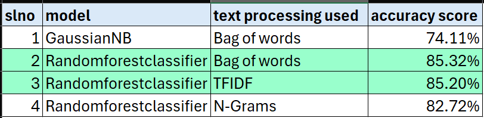

```python
print(f' The confusion matrix GaussianNB and Bag of words is \n{confusion_matrix(y_testing,y_prediction)}' )
print(f' The confusion matrix RandomForestclassifier and Bag of words is \n{confusion_matrix(y_testing,yrf_prediction)}' )
print(f' The confusion matrix RandomForestclassifier and TFIDF is \n{confusion_matrix(y_testing,yrf_predect_improv)}' )
print(f' The confusion matrix RandomForestclassifier with hyperparametric tuning, Ngrams is \n{confusion_matrix(y_testing,yrf_pred_ngrams)}' )
```

```
 The confusion matrix GaussianNB and Bag of words is
[[4767  764]
 [2060 3318]]
 The confusion matrix RandomForestclassifier and Bag of words is
[[4725  806]
 [ 795 4583]]
 The confusion matrix RandomForestclassifier and TFIDF is
[[4752  779]
 [ 835 4543]]
 The confusion matrix RandomForestclassifier with hyperparametric tuning, Ngrams is
[[4243 1288]
 [ 596 4782]]
```

🚩 Limitation:: There is a memory error while using all the features in the text preprocessing step so we are considering frequently used Top 10000 feautures for our model traininig, the error can be observed as below snap

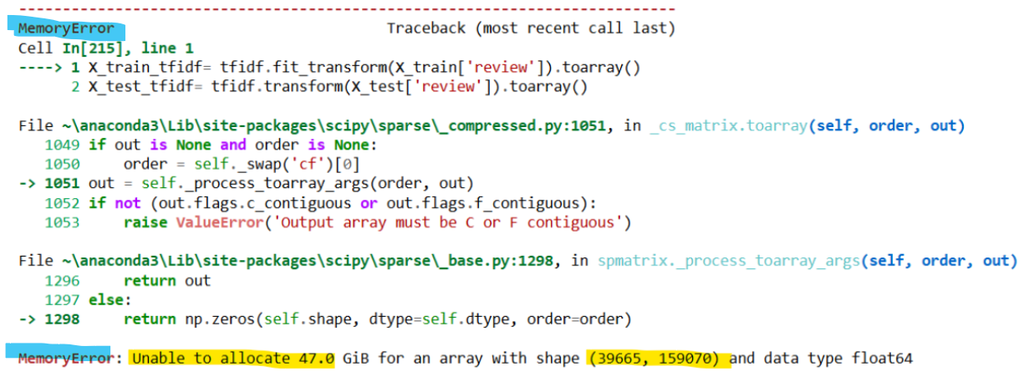